# Skrypty geoprzetwarzania

Przetwarzanie danych wektorowych

Author

Krzysztof Dyba

```r
library("terra")
```

# Wstęp

Wczytajmy dane wektorowe Luksemburgu wykorzystane na pierwszych zajęciach.

```r
sciezka = system.file("ex/lux.shp", package = "terra")
wektor = vect(sciezka)
wektor
```

```
 class       : SpatVector
 geometry    : polygons
 dimensions  : 12, 6  (geometries, attributes)
 extent      : 5.74414, 6.528252, 49.44781, 50.18162  (xmin, xmax, ymin, ymax)
 source      : lux.shp
 coord. ref. : lon/lat WGS 84 (EPSG:4326)
 names       :  ID_1   NAME_1  ID_2   NAME_2  AREA       POP
 type        : <num>    <chr> <num>    <chr> <num>     <num>
 values      :     1 Diekirch     1 Clervaux   312 1.808e+04
                   1 Diekirch     2 Diekirch   218 3.254e+04
                   1 Diekirch     3  Redange   259 1.866e+04
```

Warto zauważyć, że funkcja `vect()` poza standardowym odczytem oferuje więcej zaawansowanych możliwości:

- wczytanie określonego zakresu przestrzennego
- wczytanie określonych warstw
- wczytanie określonego rodzaju danych (geometrie lub atrybuty)
- tworzenie zapytań bazodanowych (SQL)
- stworzenie wskaźnika do pliku (*proxy*)

Zasadniczo, do atrybutów warstwy wektorowej możemy odwołać się na dwa sposoby używając:

- znaku dolara `$` – zwraca wektor bez geometrii
- nawiasu kwadratowego `[]` – zwraca geometrię z wybranymi atrybutami

```r
wektor$NAME_2
```

```
 [1] "Clervaux"         "Diekirch"         "Redange"          "Vianden"
 [5] "Wiltz"            "Echternach"       "Remich"           "Grevenmacher"
 [9] "Capellen"         "Esch-sur-Alzette" "Luxembourg"       "Mersch"
```

```r
wektor[, "NAME_2"]
```

```
 class       : SpatVector
 geometry    : polygons
 dimensions  : 12, 1  (geometries, attributes)
 extent      : 5.74414, 6.528252, 49.44781, 50.18162  (xmin, xmax, ymin, ymax)
 source      : lux.shp
 coord. ref. : lon/lat WGS 84 (EPSG:4326)
 names       :   NAME_2
 type        :    <chr>
 values      : Clervaux
               Diekirch
                Redange
```

Oprócz tego, możemy pozyskać wszystkie atrybuty w postaci ramki danych używając funkcji `as.data.frame()`.

# Operacje

## Obliczanie powierzchni

W celu obliczenia powierzchni poligonów należy zastosować funkcję `expanse()`. Ta funkcja automatycznie wykonuje obliczenia dla układów wyrażonych w stopniach, więc nie jest wymagana projekcja do planarnego układu współrzędnych. Można również określić jednostki, w których zwrócone będą wyniki przy pomocy argumentu `unit`.

```r
powierzchnia = expanse(wektor, unit = "km")
data.frame(nazwa = wektor$NAME_2, powierzchnia)
```

```
              nazwa powierzchnia
1          Clervaux    312.28321
2          Diekirch    218.67403
3           Redange    259.45481
4           Vianden     76.20041
5             Wiltz    263.17426
6        Echternach    188.28214
7            Remich    128.99150
8      Grevenmacher    210.35449
9          Capellen    185.63077
10 Esch-sur-Alzette    251.32202
11       Luxembourg    237.11300
12           Mersch    233.32996
```

## Generowanie punktów

Można wygenerować punkty o rozkładzie regularnym (`method = "regular"`) lub losowych (`method = "random"`) na podstawie wejściowej geometrii używając funkcji `spatSample()`. Istnieje również możliwość próbkowania stratyfikowanego (wtedy dla każdego poligonu zostanie wygenerowanych $n$ punktów).

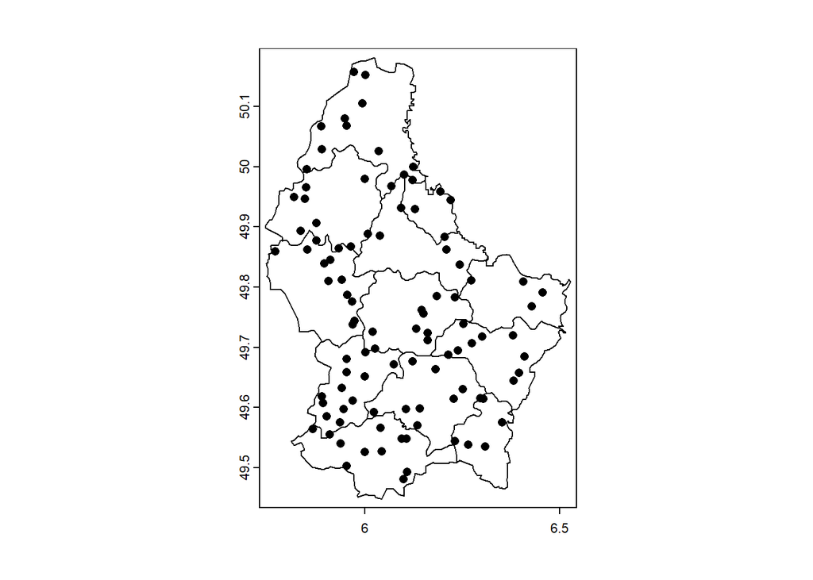

```r
proba = spatSample(wektor, size = 100, method = "random")
plot(wektor)
plot(proba, add = TRUE)
```

## Generowanie otoczki wypukłej

Otoczka wypukła jest najmniejszym wielokątem wypukłym ograniczającym dany zbiór punktów. Innymi słowy, jest to wielokąt, którego wierzchołki stanowią najbardziej zewnętrzne punkty zbioru. Do jej wygenerowania służy funkcja `convHull()`.

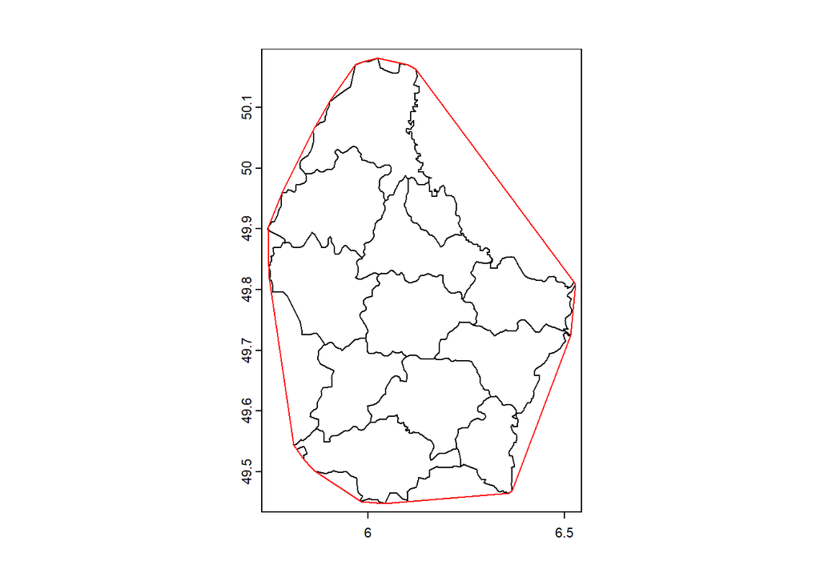

```r
otoczka = convHull(wektor)
plot(wektor)
plot(otoczka, add = TRUE, border = "red")
```

## Generowanie buforów

Bufory można wygenerować wykorzystując funkcje `buffer()`. Bufory obliczane są dla każdej geometrii osobno, w związku z czym, jeśli chcemy stworzyć jeden bufor musimy zastosować funkcję agregującą geometrie, tj. `aggregate()`; łączy ona wiele geometrii w jedną. Funkcja `buffer()` wymaga wskazania odległości bufora (argument `width`) i należy odnotować, że:

- domyślną jednostką długości dla układu geograficznego są metry (nie stopnie)
- argument `width` jest zwektoryzowany, zatem można określić różne odległości dla kolejnych geometrii

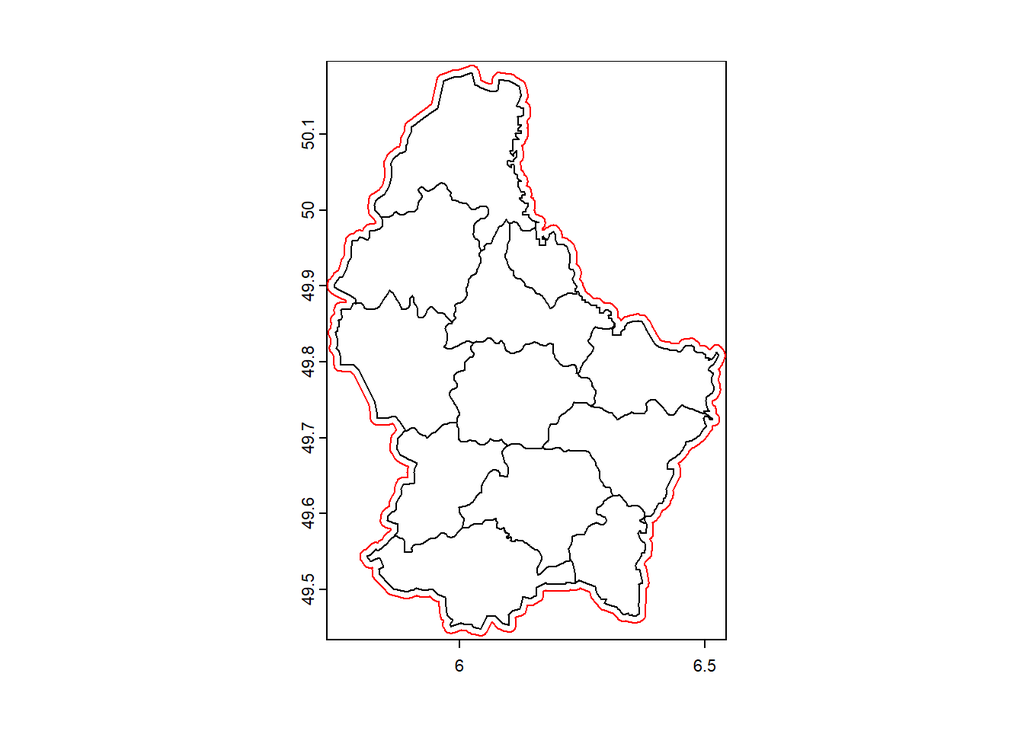

```r
bufor = buffer(aggregate(wektor), width = 1000)
plot(wektor)
plot(bufor, add = TRUE, border = "red")
```

## Generowanie centroidów

Centroid jest to punkt określający geometryczny środek wielokąta. Dla wielokątów wypukłych (tj. kąty takiej figury są mniejsze niż 180°) wyliczany jest na podstawie średniej arytmetycznej współrzędnych wierzchołków. Jego wyznaczenie jest możliwe używając funkcji `centroids()`. W przypadku wielokątów wklęsłych centroid może znajdować się poza obiektem, wtedy może zastosować argument `inside = TRUE`, który wymusi przybliżoną lokalizację wewnątrz obiektu.

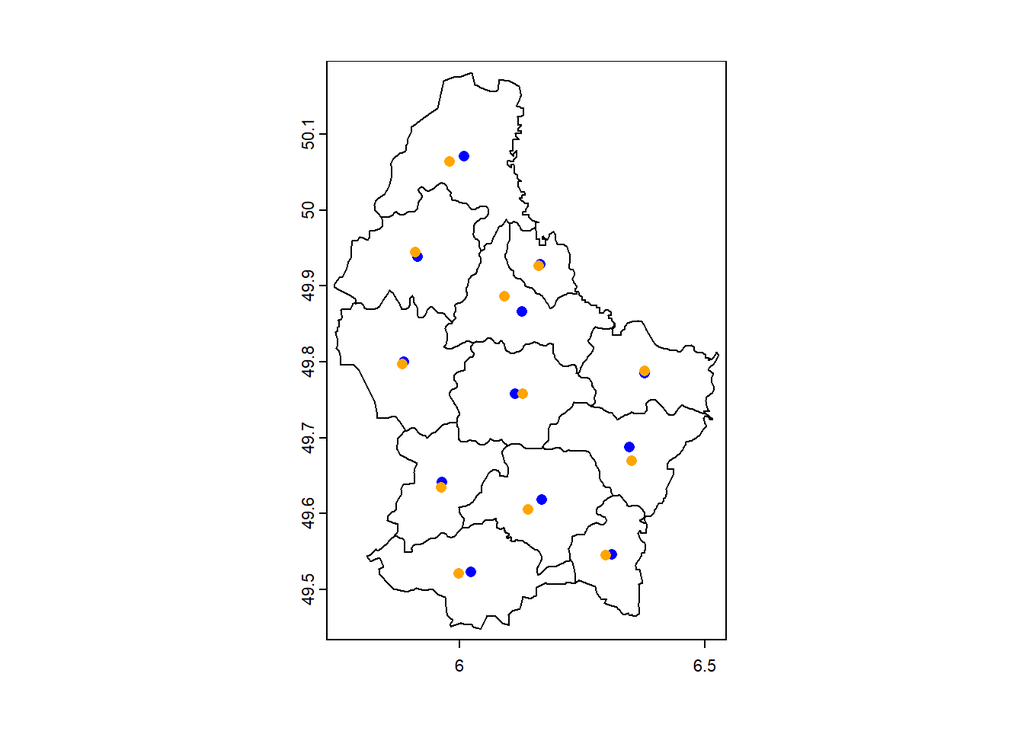

```r
centroidy = centroids(wektor, inside = FALSE)
centroidy_wewnatrz = centroids(wektor, inside = TRUE)
plot(wektor)
plot(centroidy, add = TRUE, col = "blue")
plot(centroidy_wewnatrz, add = TRUE, col = "orange")
```

## Obliczanie odległości

W kolejnym kroku możemy obliczyć jak oddalone są centroidy od siebie używając funkcję `distance()`. Wymieniona funkcja również automatycznie wykonuje obliczenia dla układów geograficznych (jednostki w stopniach) i wynik domyślnie zwracany jest w metrach. Jeśli podamy jeden argument w funkcji, to zostaną wyliczone odległości każdego obiektu z każdym.

```r
odleglosci = distance(centroidy)
```

Jako wynik otrzymujemy obiekt klasy `dist`, który reprezentuje jako wektor dolną połowę macierzy odległości. Wykorzystując funkcję `as.matrix()` możemy przetransformować ten obiekt do pełnej macierzy.

```r
macierz_odleglosci = as.matrix(odleglosci)
macierz_odleglosci[1:5, 1:5]
```

```
         1         2        3         4        5
1     0.00 24278.741 31347.51 19333.164 16142.45
2 24278.74     0.000 18823.34  7482.575 17303.64
3 31347.51 18823.339     0.00 24620.060 15567.14
4 19333.16  7482.575 24620.06     0.000 18021.71
5 16142.45 17303.638 15567.14 18021.709     0.00
```

Dla ułatwienia możemy również kolumnom i wierszom nadać nazwy jednostek administracyjnych.

```r
colnames(macierz_odleglosci) = rownames(macierz_odleglosci) = centroidy$NAME_2
# View(macierz_odleglosci) # wyświetl
```

## Relacje przestrzenne

Do określenia [relacji przestrzennych](https://en.wikipedia.org/wiki/DE-9IM) między obiektami służy funkcja `relate()`. Dla przykładu możemy sprawdzić czy poligon zawiera (`relation = "contains"`) wylosowany punkt. Jako wynik funkcji zwracana jest macierz z wartościami logicznymi.

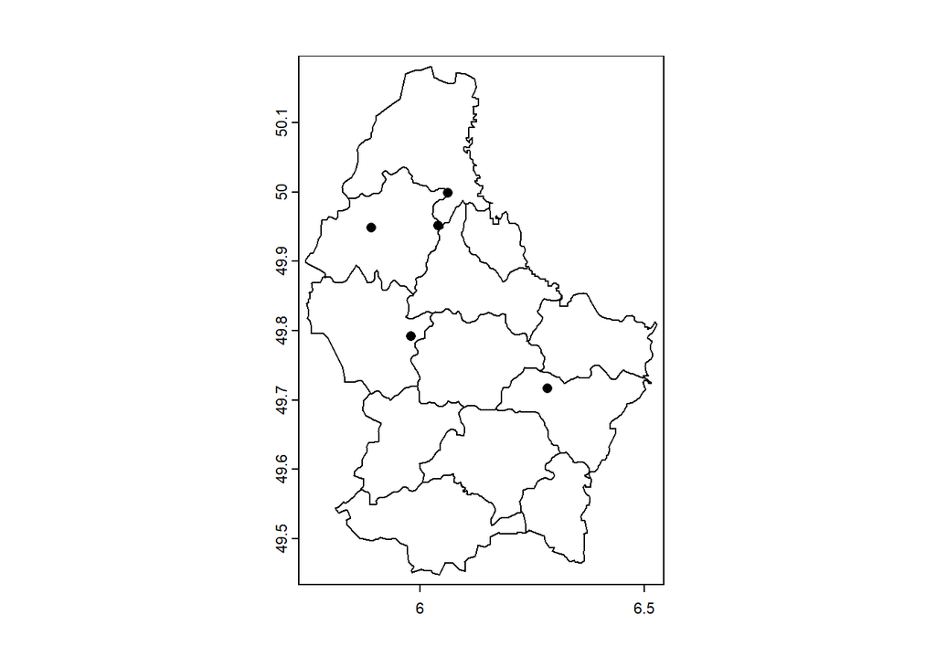

```r
proba = spatSample(wektor, size = 5, method = "random")
plot(wektor)
plot(proba, add = TRUE)
```

```r
relate(wektor, proba, relation = "contains")
```

```
       [,1]  [,2]  [,3]  [,4]  [,5]
 [1,] FALSE FALSE FALSE  TRUE FALSE
 [2,] FALSE FALSE FALSE FALSE FALSE
 [3,] FALSE  TRUE FALSE FALSE FALSE
 [4,] FALSE FALSE FALSE FALSE FALSE
 [5,] FALSE FALSE  TRUE FALSE  TRUE
 [6,] FALSE FALSE FALSE FALSE FALSE
 [7,] FALSE FALSE FALSE FALSE FALSE
 [8,]  TRUE FALSE FALSE FALSE FALSE
 [9,] FALSE FALSE FALSE FALSE FALSE
[10,] FALSE FALSE FALSE FALSE FALSE
[11,] FALSE FALSE FALSE FALSE FALSE
[12,] FALSE FALSE FALSE FALSE FALSE
```

W wierszach zawarte są jednostki administracyjne, natomiast w kolumnach wylosowane punkty.

## Docinanie

Podobnie jak w przypadku danych rastrowych, możemy zmniejszyć zasięg warstwy wektorowej używając funkcję `crop()`.

```r
zasieg = ext(c(5.9, 6.3, 49.6, 49.9))
wektor_dociety = crop(wektor, zasieg)
```

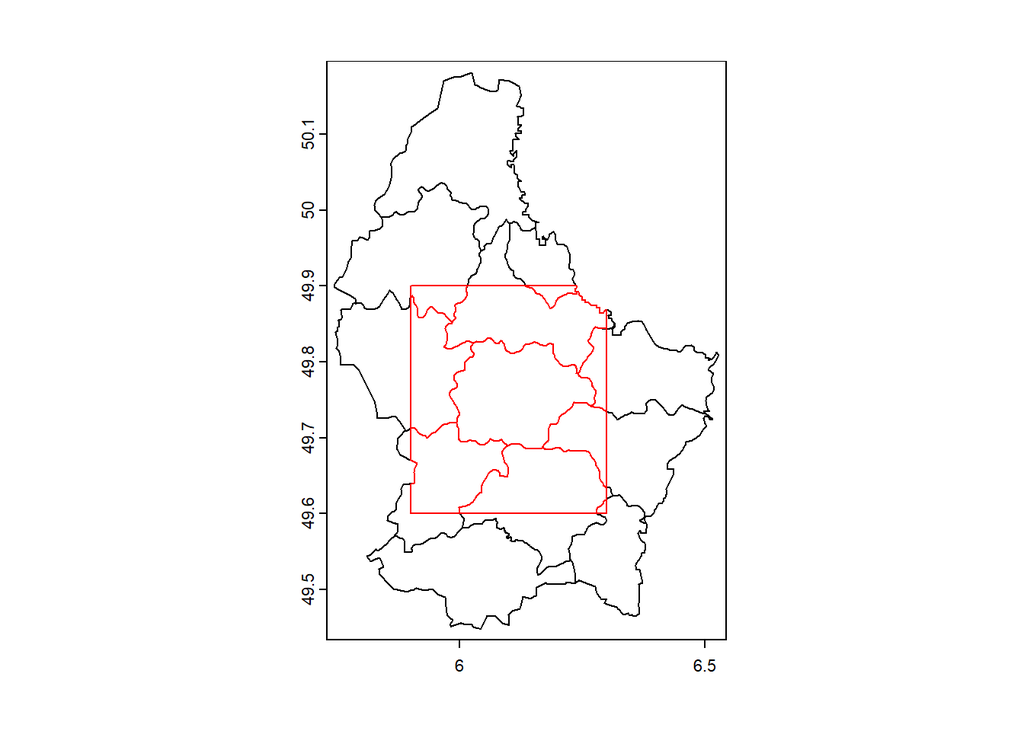

```r
plot(wektor)
plot(wektor_dociety, add = TRUE, border = "red")
```

Alternatywnie docięcie można wykonać używając funkcji `intersect()`.

## Reprojekcja

Reprojekcja danych wektorowych wygląda identycznie tak jak w przypadku danych rastrowych.

```r
wektor_3857 = project(wektor, "EPSG:3857")
```

Oczywiście w tej sekcji zostały zaprezentowane jedynie wybrane funkcje do przetwarzania danych wektorowych.

# Zadanie

4. Pobierz granice powiatów z Geoportalu, następnie wylicz ich centroidy i wskaż te powiaty, które są położone najbliżej i najdalej. Wskazówki: (1) Odległość obiektu od samego siebie wynosi 0 m i trzeba to wykluczyć. (2) Do znalezienia indeksu o minimalnej lub maksymalnej wartości można wykorzystać funkcje `which()` z argumentem `arr.ind = TRUE`.

   Zastanów się również jak na wyniki analizy wpływają miasta na prawach powiatu oraz [eksklawy powiatów](https://pl.wikipedia.org/wiki/Eksklawa#Powiaty).
5. Na stronie [https://dane.gov.pl](https://dane.gov.pl/pl/dataset/792,numeryczny-model-terenu-o-interwale-siatki-co-najmniej-100-m) znajdziesz numeryczne modele terenu w siatce 100 m dla wszystkich województw. Napisz funkcję, która umożliwi pobranie danych dla wybranego województwa przez użytkownika oraz dokona wizualizacji mediany wysokości oraz odchylenia standardowego dla powiatów.

   Dane udostępnione są w formacie tekstowym. Do ich wczytania możesz wykorzystać funkcję `read.table()`. Sprawdź jaki jest separator kolumn, separator dziesiętny, nagłówek kolumn oraz typ kolumn.